# Weekly Assignment 2

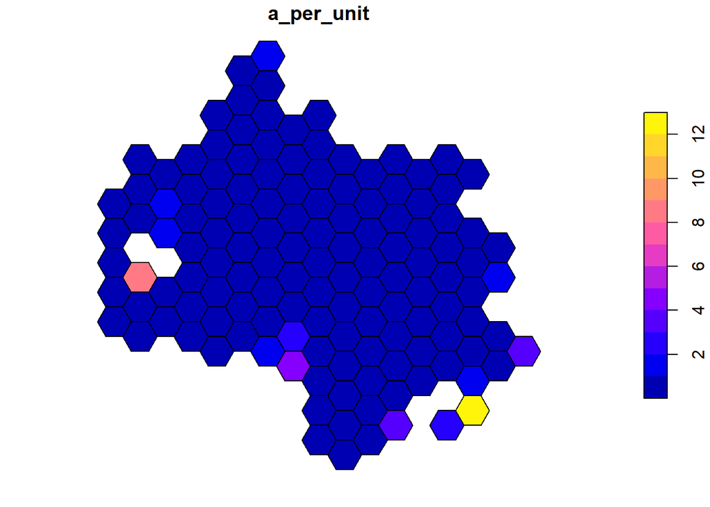

```r
plot(hex_grid['a_per_unit'])
```

```r
pal <- colorBin("magma", domain = hex_grid$units, bins = 5)
leaflet(st_transform(hex_grid, 4326)) %>%
setView(-71.108915, 42.385355, 12) %>%
addProviderTiles("Stamen.Toner") %>%
addPolygons(
fillColor = ~pal(units),
weight = 1,
opacity = 1,
color = 'white',
fillOpacity = 0.8
) %>%
addLegend(
pal = pal,
values = ~units,
opacity = 0.8,
title = NULL,
position = "bottomright")
```

[interactive chart not shown]

```r
neighborhood <- poly2nb(hex_grid, queen=FALSE)
head(neighborhood)
```

```
## [[1]]
## [1] 2 7 8
##
## [[2]]
## [1] 1 3 8
##
## [[3]]
## [1] 2 4 9
##
## [[4]]
## [1]  3  5  9 10
##
## [[5]]
## [1]  4 10 11
##
## [[6]]
## [1]  7 12
```

```r
# Rook's case neighborhood
coords <- st_coordinates(st_centroid(hex_grid))
```

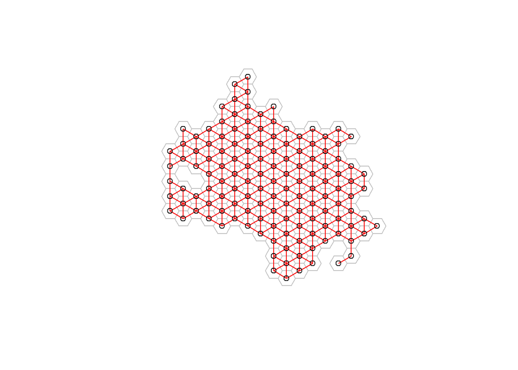

```r
plot(st_geometry(hex_grid), border='gray')
plot(neighborhood, coords, col='red', lwd=1, add=TRUE)
```

```r
# Convert to binary adjacency weight list..
listw_binary <- nb2listw(
neighbours=neighborhood,
style='B'
)
head(listw_binary$weights)
```

```
## [[1]]
## [1] 1 1 1
##
## [[2]]
## [1] 1 1 1
##
## [[3]]
## [1] 1 1 1
##
## [[4]]
## [1] 1 1 1 1
##
## [[5]]
## [1] 1 1 1
##
## [[6]]
## [1] 1 1
```

```r
# Convert to row-standardized adjacency weight list.
listw_rowst <- nb2listw(
neighbours=neighborhood,
style='W'
)
head(listw_rowst$weights)
```

```
## [[1]]
## [1] 0.3333333 0.3333333 0.3333333
##
## [[2]]
## [1] 0.3333333 0.3333333 0.3333333
##
## [[3]]
## [1] 0.3333333 0.3333333 0.3333333
##
## [[4]]
## [1] 0.25 0.25 0.25 0.25
##
## [[5]]
## [1] 0.3333333 0.3333333 0.3333333
##
## [[6]]
## [1] 0.5 0.5
```

```r
#calculating moran's I

abnb_moran_b <- moran.test(x = hex_grid$abnb_count,
listw = listw_binary)
print(abnb_moran_b)
```

```
##
##  Moran I test under randomisation
##
## data:  hex_grid$abnb_count
## weights: listw_binary
##
## Moran I statistic standard deviate = 12.755, p-value < 2.2e-16
## alternative hypothesis: greater
## sample estimates:
## Moran I statistic       Expectation          Variance
##       0.662394180      -0.007462687       0.002758074
```

```r
abnb_geary_b <- geary.test(x = hex_grid$abnb_count,
listw = listw_binary)
print(abnb_geary_b)
```

```
##
##  Geary C test under randomisation
##
## data:  hex_grid$abnb_count
## weights: listw_binary
##
## Geary C statistic standard deviate = 9.0402, p-value < 2.2e-16
## alternative hypothesis: Expectation greater than statistic
## sample estimates:
## Geary C statistic       Expectation          Variance
##       0.373989144       1.000000000       0.004795245
```

```r
housing_moran_b <- moran.test(x = hex_grid$units,
listw = listw_binary)
print(housing_moran_b)
```

```
##
##  Moran I test under randomisation
##
## data:  hex_grid$units
## weights: listw_binary
##
## Moran I statistic standard deviate = 10.121, p-value < 2.2e-16
## alternative hypothesis: greater
## sample estimates:
## Moran I statistic       Expectation          Variance
##       0.531370224      -0.007462687       0.002834157
```

```r
housing_geary_b <- geary.test(x = hex_grid$units,
listw = listw_binary)
print(housing_geary_b)
```

```
##
##  Geary C test under randomisation
##
## data:  hex_grid$units
## weights: listw_binary
##
## Geary C statistic standard deviate = 9.4367, p-value < 2.2e-16
## alternative hypothesis: Expectation greater than statistic
## sample estimates:
## Geary C statistic       Expectation          Variance
##       0.470161271       1.000000000       0.003152467
```

Moran’s I statistic for AirBnbs using a binary weight’s list is 0.66 with a significant p value. Moran’s I statistic for Housing units using a binary weight’s list is 0.53 with a significant p value. Both AirBnbs are highly clustered with AirBnBs having a slightly higher propensity for clustering.

Similar results are found in the Geary calculation. Both Housing and AirBnB units have a Geary C statistic lower than one indicating positive spatial autocorrelation. In addition, the p value is less than 0.05 so we must reject the null hypothesis.

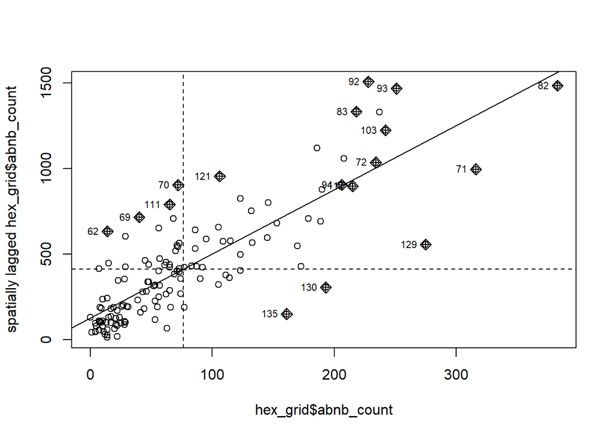

```r
moran.plot(hex_grid$abnb_count, listw_binary)
```

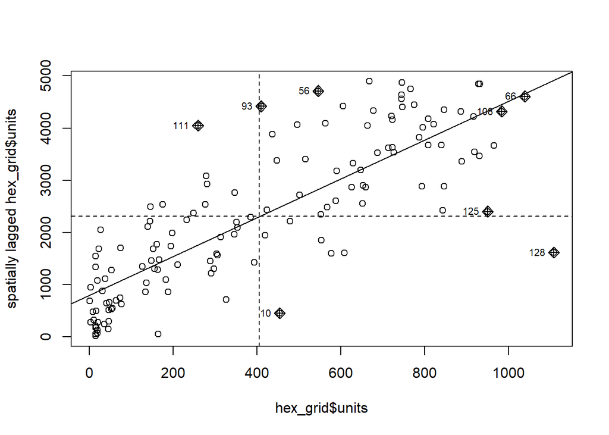

```r
moran.plot(hex_grid$units, listw_binary)
```

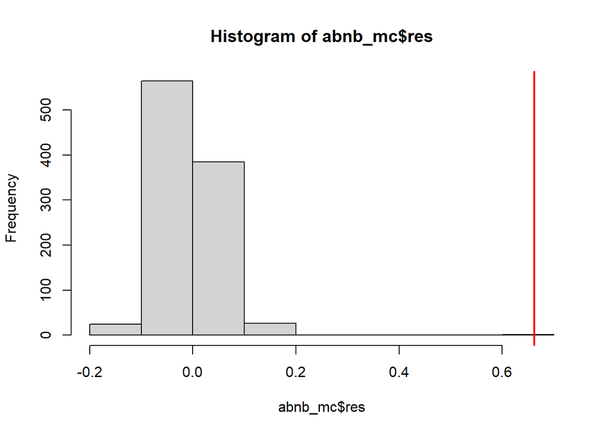

```r
abnb_mc <- moran.mc(hex_grid$abnb_count, listw_binary, nsim=999)
hist(abnb_mc$res)
abline(v=abnb_mc['statistic'], col='red', lwd=2)
```

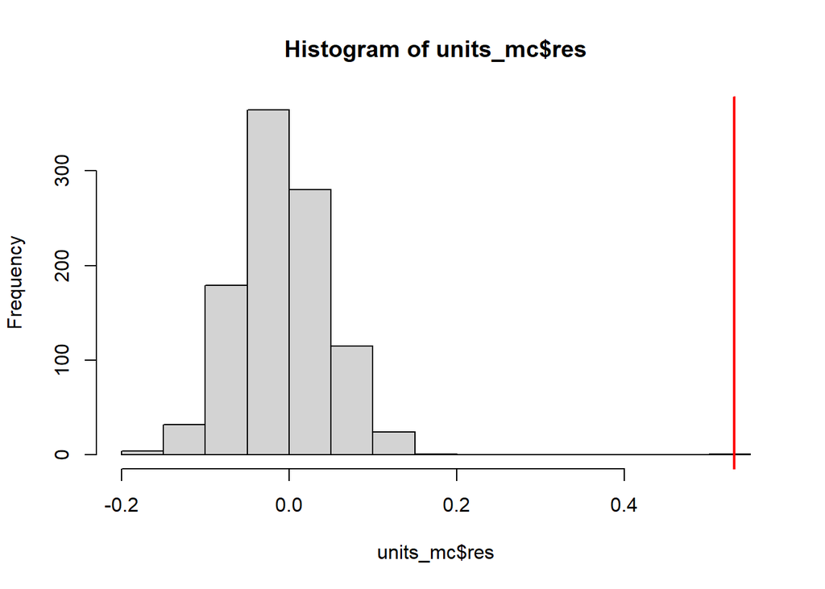

```r
units_mc <- moran.mc(hex_grid$units, listw_binary, nsim=999)
hist(units_mc$res)
abline(v=units_mc['statistic'], col='red', lwd=2)
```

```r
abnb_moran_r <- moran.test(x = hex_grid$abnb_count,
listw = listw_rowst)
housing_moran_r <- moran.test(x = hex_grid$units,
listw = listw_rowst)
print(abnb_moran_b)
```

```
##
##  Moran I test under randomisation
##
## data:  hex_grid$abnb_count
## weights: listw_binary
##
## Moran I statistic standard deviate = 12.755, p-value < 2.2e-16
## alternative hypothesis: greater
## sample estimates:
## Moran I statistic       Expectation          Variance
##       0.662394180      -0.007462687       0.002758074
```

```r
print(abnb_moran_r)
```

```
##
##  Moran I test under randomisation
##
## data:  hex_grid$abnb_count
## weights: listw_rowst
##
## Moran I statistic standard deviate = 11.616, p-value < 2.2e-16
## alternative hypothesis: greater
## sample estimates:
## Moran I statistic       Expectation          Variance
##       0.629933356      -0.007462687       0.003011049
```

```r
print(housing_moran_b)
```

```
##
##  Moran I test under randomisation
##
## data:  hex_grid$units
## weights: listw_binary
##
## Moran I statistic standard deviate = 10.121, p-value < 2.2e-16
## alternative hypothesis: greater
## sample estimates:
## Moran I statistic       Expectation          Variance
##       0.531370224      -0.007462687       0.002834157
```

```r
print(housing_moran_r)
```

```
##
##  Moran I test under randomisation
##
## data:  hex_grid$units
## weights: listw_rowst
##
## Moran I statistic standard deviate = 9.6265, p-value < 2.2e-16
## alternative hypothesis: greater
## sample estimates:
## Moran I statistic       Expectation          Variance
##       0.528043021      -0.007462687       0.003094477
```

```r
centroids <- st_centroid(hex_grid)
distances <- st_distance(centroids, centroids) %>%
set_units(NULL)
distances[distances > 2640] <- 0

miler <- st_distance(centroids, centroids) %>%
set_units(NULL)
miler[miler > 5280] <- 0
```

```r
inverse_dist <- ifelse(distances!=0, 1/(distances^2),distances)
inverse_miler <- ifelse(miler!=0, 1/(miler^2),miler)
```

```r
inverse_dist_listw <- mat2listw(inverse_dist, style="W")
inverse_miler_listw <- mat2listw(inverse_miler, style="W")

moran.test(x = hex_grid$abnb_count, listw = inverse_dist_listw)
```

```
##
##  Moran I test under randomisation
##
## data:  hex_grid$abnb_count
## weights: inverse_dist_listw
##
## Moran I statistic standard deviate = 11.616, p-value < 2.2e-16
## alternative hypothesis: greater
## sample estimates:
## Moran I statistic       Expectation          Variance
##       0.629933356      -0.007462687       0.003011049
```

```r
moran.test(x = hex_grid$abnb_count, listw = inverse_miler_listw)
```

```
##
##  Moran I test under randomisation
##
## data:  hex_grid$abnb_count
## weights: inverse_miler_listw
##
## Moran I statistic standard deviate = 16.773, p-value < 2.2e-16
## alternative hypothesis: greater
## sample estimates:
## Moran I statistic       Expectation          Variance
##       0.523488010      -0.007462687       0.001002095
```

```r
moran.test(x = hex_grid$units, listw = inverse_dist_listw)
```

```
##
##  Moran I test under randomisation
##
## data:  hex_grid$units
## weights: inverse_dist_listw
##
## Moran I statistic standard deviate = 9.6265, p-value < 2.2e-16
## alternative hypothesis: greater
## sample estimates:
## Moran I statistic       Expectation          Variance
##       0.528043021      -0.007462687       0.003094477
```

```r
moran.test(x = hex_grid$units, listw = inverse_miler_listw)
```

```
##
##  Moran I test under randomisation
##
## data:  hex_grid$units
## weights: inverse_miler_listw
##
## Moran I statistic standard deviate = 12.825, p-value < 2.2e-16
## alternative hypothesis: greater
## sample estimates:
## Moran I statistic       Expectation          Variance
##       0.404101209      -0.007462687       0.001029846
```

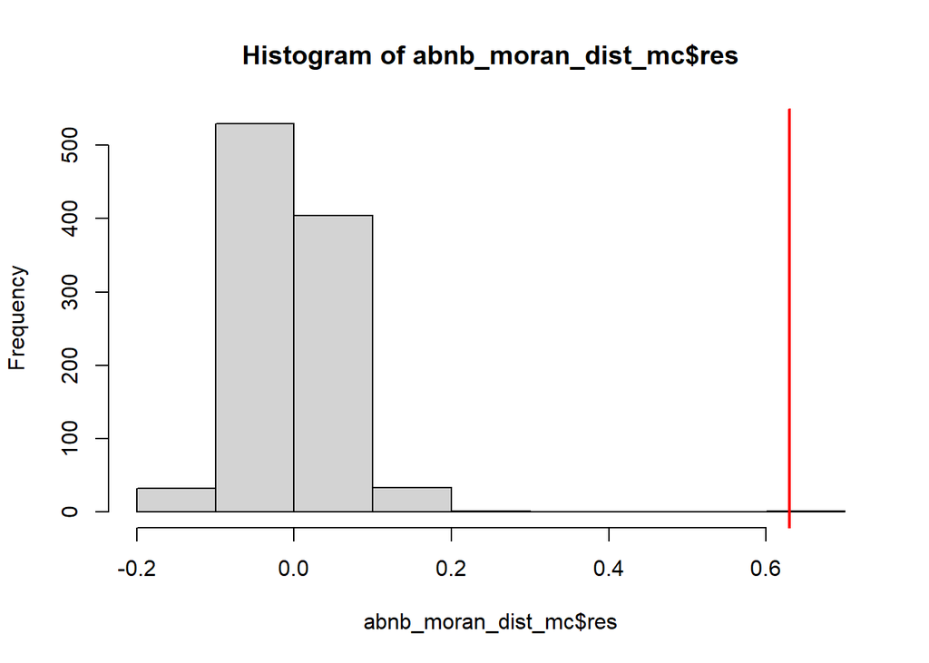

```r
abnb_moran_dist_mc <- moran.mc(hex_grid$abnb_count, inverse_dist_listw, nsim=999)
hist(abnb_moran_dist_mc$res)
abline(v=abnb_moran_dist_mc['statistic'], col='red', lwd=2)
```

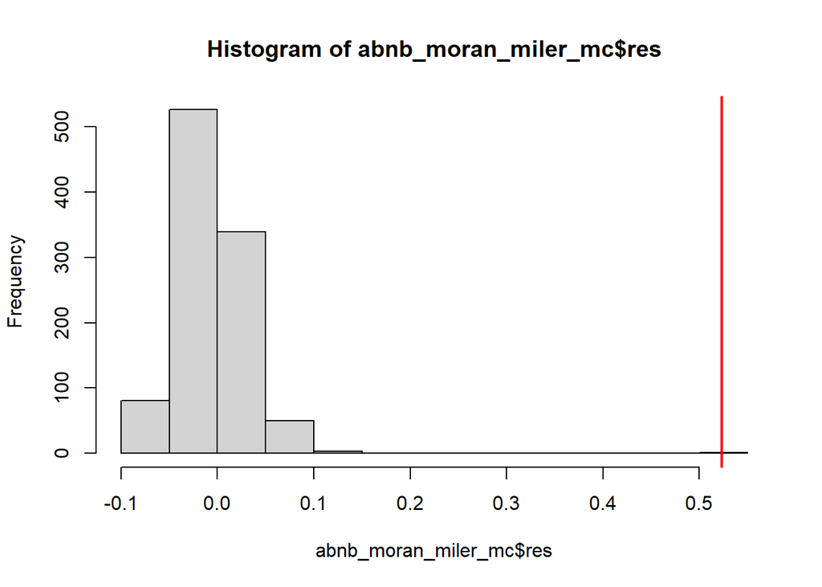

```r
abnb_moran_miler_mc <- moran.mc(hex_grid$abnb_count, inverse_miler_listw, nsim=999)
hist(abnb_moran_miler_mc$res)
abline(v=abnb_moran_miler_mc['statistic'], col='red', lwd=2)
```